# Assignment_3_Finished

## Assignment 3

**TU Delft and WUR**  
**Q1 2024**  
**Instructor:** Theodoros Chatzivasileiadis  
**Instructor:** Hans Hoogenboom  
**TA:** Ka Yi Chua  
**[Metropolitan Data 1](https://jhoogenboom.github.io/spatial-data-science/_index.html)**

**This homework assignment document will guide you through five tasks in cleaning your data.**

1. Reading and Summarizing the Data.
2. Subsetting the Data.
3. Manage Missing Data.
4. Shape the Data.
5. Saving the Results.

# NB: From now on you should submit 1) your notebook with the answers, remember that comments are good practice, 2) a working Git page with your assignment

## Exercise 1: Loading the data:

- Load the `goodreads.csv` file into Python
- Explore it by looking at first and last 5 rows
- Change the column names to `["rating", 'review_count', 'isbn', 'booktype','author_url', 'year', 'genre_urls', 'dir','rating_count', 'name']`

```python
#-----------------------  LOAD CSV AND PRINT FIRST 5 ROWS ------------------
#Libraries
import pandas as pd

#import the dataframe goodreads.csv, set header to none since there is no header in the csv
df = pd.read_csv('/Users/pietro/Documents/UNI/MADE/Data1/lab-02/data/goodreads.csv', header = None)

#exploring first five rows
print("-----------------------")
print("First five rows:")
print("-----------------------")
df.head()
#------------------------------------------------------------------------
```

```
-----------------------
First five rows:
-----------------------
```

|  | 0 | 1 | 2 | 3 | 4 | 5 | 6 | 7 | 8 | 9 |
| --- | --- | --- | --- | --- | --- | --- | --- | --- | --- | --- |
| 0 | 4.40 | 136455.0 | 0439023483 | good_reads:book | https://www.goodreads.com/author/show/153394.S... | 2008.0 | /genres/young-adult\|/genres/science-fiction\|/g... | dir01/2767052-the-hunger-games.html | 2958974.0 | The Hunger Games (The Hunger Games, #1) |
| 1 | 4.41 | 16648.0 | 0439358078 | good_reads:book | https://www.goodreads.com/author/show/1077326.... | 2003.0 | /genres/fantasy\|/genres/young-adult\|/genres/fi... | dir01/2.Harry_Potter_and_the_Order_of_the_Phoe... | 1284478.0 | Harry Potter and the Order of the Phoenix (Har... |
| 2 | 3.56 | 85746.0 | 0316015849 | good_reads:book | https://www.goodreads.com/author/show/941441.S... | 2005.0 | /genres/young-adult\|/genres/fantasy\|/genres/ro... | dir01/41865.Twilight.html | 2579564.0 | Twilight (Twilight, #1) |
| 3 | 4.23 | 47906.0 | 0061120081 | good_reads:book | https://www.goodreads.com/author/show/1825.Har... | 1960.0 | /genres/classics\|/genres/fiction\|/genres/histo... | dir01/2657.To_Kill_a_Mockingbird.html | 2078123.0 | To Kill a Mockingbird |
| 4 | 4.23 | 34772.0 | 0679783261 | good_reads:book | https://www.goodreads.com/author/show/1265.Jan... | 1813.0 | /genres/classics\|/genres/fiction\|/genres/roman... | dir01/1885.Pride_and_Prejudice.html | 1388992.0 | Pride and Prejudice |

```python
#---------------------- LAST FIVE ROWS ----------------------
print("-----------------------")
print("Last five rows:")
print("-----------------------")
df.tail()
#--------------------------------------------------------------
```

```
-----------------------
Last five rows:
-----------------------
```

|  | 0 | 1 | 2 | 3 | 4 | 5 | 6 | 7 | 8 | 9 |
| --- | --- | --- | --- | --- | --- | --- | --- | --- | --- | --- |
| 5995 | 4.17 | 2226.0 | 0767913736 | good_reads:book | https://www.goodreads.com/author/show/44565.Ca... | 2005.0 | /genres/history\|/genres/non-fiction\|/genres/bi... | dir60/78508.The_River_of_Doubt.html | 16618.0 | The River of Doubt |
| 5996 | 3.99 | 775.0 | 1416909427 | good_reads:book | https://www.goodreads.com/author/show/151371.J... | 2006.0 | /genres/young-adult\|/genres/realistic-fiction\|... | dir60/259068.Shug.html | 6179.0 | Shug |
| 5997 | 3.78 | 540.0 | 1620612321 | good_reads:book | https://www.goodreads.com/author/show/5761314.... | 2012.0 | /genres/contemporary\|/genres/romance\|/genres/y... | dir60/13503247-flawed.html | 2971.0 | Flawed |
| 5998 | 3.91 | 281.0 | NaN | good_reads:book | https://www.goodreads.com/author/show/1201952.... | 2006.0 | /genres/religion\|/genres/islam\|/genres/religio... | dir60/2750008.html | 3083.0 | Ø£Ø³Ø¹Ø¯ Ø§Ù Ø±Ø£Ø© ÙÙ Ø§ÙØ¹Ø§ÙÙ |
| 5999 | 4.35 | 61.0 | 0786929081 | good_reads:book | https://www.goodreads.com/author/show/1023510.... | 2001.0 | /genres/fiction\|/genres/fantasy\|/genres/magic\|... | dir60/66677.Legacy_of_the_Drow_Collector_s_Edi... | 3982.0 | Legacy of the Drow Collector's Edition (Legacy... |

```python
#---------------------------------------------- CHANGE COLUMN NAMES ---------------------------------------------------------
# change the column names with .columns function
df.columns = ['rating', 'review_count', 'isbn', 'booktype','author_url', 'year', 'genre_urls', 'dir','rating_count', 'name']
df.head()
#----------------------------------------------------------------------------------------------------------------------------
```

|  | rating | review_count | isbn | booktype | author_url | year | genre_urls | dir | rating_count | name |
| --- | --- | --- | --- | --- | --- | --- | --- | --- | --- | --- |
| 0 | 4.40 | 136455.0 | 0439023483 | good_reads:book | https://www.goodreads.com/author/show/153394.S... | 2008.0 | /genres/young-adult\|/genres/science-fiction\|/g... | dir01/2767052-the-hunger-games.html | 2958974.0 | The Hunger Games (The Hunger Games, #1) |
| 1 | 4.41 | 16648.0 | 0439358078 | good_reads:book | https://www.goodreads.com/author/show/1077326.... | 2003.0 | /genres/fantasy\|/genres/young-adult\|/genres/fi... | dir01/2.Harry_Potter_and_the_Order_of_the_Phoe... | 1284478.0 | Harry Potter and the Order of the Phoenix (Har... |
| 2 | 3.56 | 85746.0 | 0316015849 | good_reads:book | https://www.goodreads.com/author/show/941441.S... | 2005.0 | /genres/young-adult\|/genres/fantasy\|/genres/ro... | dir01/41865.Twilight.html | 2579564.0 | Twilight (Twilight, #1) |
| 3 | 4.23 | 47906.0 | 0061120081 | good_reads:book | https://www.goodreads.com/author/show/1825.Har... | 1960.0 | /genres/classics\|/genres/fiction\|/genres/histo... | dir01/2657.To_Kill_a_Mockingbird.html | 2078123.0 | To Kill a Mockingbird |
| 4 | 4.23 | 34772.0 | 0679783261 | good_reads:book | https://www.goodreads.com/author/show/1265.Jan... | 1813.0 | /genres/classics\|/genres/fiction\|/genres/roman... | dir01/1885.Pride_and_Prejudice.html | 1388992.0 | Pride and Prejudice |

Codes from our group were very similar. Main difference was the use of header = None during the read_csv operation. This code prevents to put the first row as a hearder. Another solution took it into consideration only during the changing of column names part but with this solution the first row of the dataset gets lost.

## Exercise 2: Subsetting the data

- Subset the data by creating new dataframe only with `["rating", 'isbn', 'author_url', 'year', 'genre_urls', 'name']`

```python
#--------------------------- EXERCISE 2, SUBSETTING THE DATA ----------------------------
#create the new df that is a copy of the previous df with only certain columns
new_df = df[['rating', 'isbn', 'author_url', 'year', 'genre_urls', 'name']]

#printing
new_df.head()
#----------------------------------------------------------------------------------------
```

|  | rating | isbn | author_url | year | genre_urls | name |
| --- | --- | --- | --- | --- | --- | --- |
| 0 | 4.40 | 0439023483 | https://www.goodreads.com/author/show/153394.S... | 2008.0 | /genres/young-adult\|/genres/science-fiction\|/g... | The Hunger Games (The Hunger Games, #1) |
| 1 | 4.41 | 0439358078 | https://www.goodreads.com/author/show/1077326.... | 2003.0 | /genres/fantasy\|/genres/young-adult\|/genres/fi... | Harry Potter and the Order of the Phoenix (Har... |
| 2 | 3.56 | 0316015849 | https://www.goodreads.com/author/show/941441.S... | 2005.0 | /genres/young-adult\|/genres/fantasy\|/genres/ro... | Twilight (Twilight, #1) |
| 3 | 4.23 | 0061120081 | https://www.goodreads.com/author/show/1825.Har... | 1960.0 | /genres/classics\|/genres/fiction\|/genres/histo... | To Kill a Mockingbird |
| 4 | 4.23 | 0679783261 | https://www.goodreads.com/author/show/1265.Jan... | 1813.0 | /genres/classics\|/genres/fiction\|/genres/roman... | Pride and Prejudice |

The code here was EXACTLY the same for us!! (never happens!!)

## Exercise 3: Manage Missing Data

We’ve got a number of ways in general of dealing with missing data. These involve

1. Dropping off cases (or rows) in the data with any missing variables
2. Excluding variables in the data with any missing data
3. Selectively choosing indicators with only a limited amount of missing data
4. Replacing missing variables with averages, or other representative values
5. Creating a separate model to predict missing data
- Count the missing values in each column
- Manage the missing values (delete or replace values or leave them as they are) and briefly explain your choice for each column

```python
#I'm choosing to operate on the first dataset with all the columns since it's not specified which one to use

#---------------------------- COUNTING MISSING VALUES ---------------------------
#using .isna() I select the NaN values. Using .sum I count them
nan_per_column = df.isna().sum()

#prints
print("-------------------------------------")
print("The missing values per column are: ")
print("-------------------------------------")    #visual purposes
print(nan_per_column)
#---------------------------------------------------------------------------------



# -------------------------------MANAGE MISSING VALUES ------------------------------
#the missing values in this case are gonna be left like they are since it's not possible to
#replace them with representative values (due to the nature of the indicators):
#columns are "rating", 'review_count', 'isbn', 'booktype','author_url', 'year', 'genre_urls',
#'dir','rating_count', 'name'.


#Booktypes are the only values that we are changing to uknown
df['booktype']=df['booktype'].fillna("unknown")



'''
# OTHER POSSIBILITIES

 1) Rating count and review count
 Using median() value to replace the misisng values,
 is because some book could get very high count(outliers),
 this is try to not affected by this outliers.

df['rating_count']=df['rating_count'].fillna(df['rating_count'].median())
df['review_count']=df['review_count'].fillna(df['review_count'].median())

2) Rating
# Using .mean() value to replace the missing values, which would not affecting overall trends

#df['rating']=df['rating'].fillna(df['rating'].mean())
'''
#-------------------------------------------------------------------------------------
```

```
-------------------------------------
The missing values per column are:
-------------------------------------
rating            2
review_count      2
isbn            477
booktype          2
author_url        2
year              7
genre_urls       62
dir               0
rating_count      2
name              2
dtype: int64
```

[output not shown]

FIRST PART - COUNTING MISSING VALUES Differences here stood in using different functions: .isnull() or .isna() but both brought us to the same results.

SECOND PART - MANAGING MISSING VALUES Here we all managed the missing data differently. This brought us to have arguments on how to handle the dataset. In the end we opted to leave most of the fields untouched since any replacement would have altered the dataset. This was the deciding factor that made us change only the booktype field, turning the NaN values into "unknown". The possible changes were, for example in the 'rating': one of us changed the NaN value with the mean of the ratings. This is a possible option and it is in the code as a comment under #OTHER POSSIBILITIES. The nice aspect of this substitution stands in the fact that it doesn't affect the overall trends. Another example was to use the median to not get the result affected by the presence of outliers. This is also shown under OTHER POSSIBILITIES for the rating count and the review count. We didn't decide to make any of this changes due to our desire of not altering the dataset.

## Exercise 4: Shape the data

- Parse the `author_url` to create new column named `author`
- Sort the data by putting higher rates go first. If there are overlapping rates, try to put earlier years go first.
- **(Stretch Goal)** Examine how many books were published at each year and find lowest, highest rate of each year.

```python
#--------------------------------- ADDING THE AUTHOR ---------------------------------------------

# 1) to add the author first we need to add the author column: df['author']

# 2) then we have to divide the cases where the name is actually in the url
# from the ones where the name is missing: see if / else at the end of the line

# 3) we have to read through the url till the last / character and split the string there:
# x.split('/')[-1] allows this.

# 4) we have to exlude what's before the . character: .split('.')[-1]

df['author'] = df['author_url'].apply(lambda x: x.split('/')[-1].split('.')[-1].replace('_', ' ') if pd.notnull(x) else "uknown")

print("------------------------------------")
print("Here are the first five authors")
print("------------------------------------")
df[['author_url', 'author']].head()
#-------------------------------------------------------------------------------------------------
```

```
------------------------------------
Here are the first five authors
------------------------------------
```

|  | author_url | author |
| --- | --- | --- |
| 0 | https://www.goodreads.com/author/show/153394.S... | Suzanne Collins |
| 1 | https://www.goodreads.com/author/show/1077326.... | J K Rowling |
| 2 | https://www.goodreads.com/author/show/941441.S... | Stephenie Meyer |
| 3 | https://www.goodreads.com/author/show/1825.Har... | Harper Lee |
| 4 | https://www.goodreads.com/author/show/1265.Jan... | Jane Austen |

```python
#--------------------------------------- SORTING ------------------------------------------
# Sort the data by 'rating' (ascending = false ) and then by 'year' (ascending = true) with
# the .sort_values funcion
df_sorted = df.sort_values(by=['rating', 'year'], ascending=[False, True])

#visual representation of the sorting
print("-------------------------------")
print("Here's the sorted dataset: ")
print("-------------------------------")
df_sorted[['rating','year']]

#-------------------------------------------------------------------------------------------
```

```
-------------------------------
Here's the sorted dataset:
-------------------------------
```

|  | rating | year |
| --- | --- | --- |
| 2909 | 5.00 | 2011.0 |
| 2145 | 5.00 | 2012.0 |
| 2903 | 5.00 | 2012.0 |
| 4473 | 5.00 | 2012.0 |
| 5692 | 5.00 | 2012.0 |
| ... | ... | ... |
| 2609 | 2.90 | 2013.0 |
| 5979 | 2.77 | 2001.0 |
| 3738 | 2.00 | 2011.0 |
| 3643 | NaN | NaN |
| 5282 | NaN | NaN |

6000 rows × 2 columns

```python
#------------------------------ HIGHEST / LOWEST RATE OF THE YEAR -------------------------------

# Grouping the data by 'year' and aggregating to get the number of books, min and max rating
# .agg() used to apply multiple aggregating functions

yearly_stats = df.groupby('year').agg(
    books_published=('name', 'count'),     # Count how many books were published each year
    lowest_rating=('rating', 'min'),       # Find the lowest rating for each year
    highest_rating=('rating', 'max')       # Find the highest rating for each year
).reset_index()

yearly_stats

#---------------------------------------------------------------------------------------------
```

|  | year | books_published | lowest_rating | highest_rating |
| --- | --- | --- | --- | --- |
| 0 | -1500.0 | 1 | 3.60 | 3.60 |
| 1 | -800.0 | 2 | 3.68 | 4.01 |
| 2 | -560.0 | 1 | 4.03 | 4.03 |
| 3 | -512.0 | 1 | 3.92 | 3.92 |
| 4 | -500.0 | 1 | 4.06 | 4.06 |
| ... | ... | ... | ... | ... |
| 288 | 2010.0 | 317 | 3.08 | 4.93 |
| 289 | 2011.0 | 374 | 2.00 | 5.00 |
| 290 | 2012.0 | 355 | 3.15 | 5.00 |
| 291 | 2013.0 | 276 | 2.90 | 4.93 |
| 292 | 2014.0 | 87 | 3.31 | 5.00 |

293 rows × 4 columns

As for the ADDING THE AUTHOR PART one of us defined a function that could return the name of the author and than used that function for all values of the url column. This solution was still using .split() and focusing on the / and . characters to retrieve the name. Another difference stood in the usage of pd.notnull(x) else "uknown" that made the code more resilient to NaN values by giving unknown as an author name. Last deciding factors were taht this code looked more readable, simple to understand and the display of the result was more clear.

As for the SORTING PART one of us didn't take into account the fact that, while the rating is descending ( ascending=[False] ) the year has to be ascending. So the right code has to have ( ascending=[False, True] ) for rating and year.

For the highest and lowest rates of the year our codes were basically identical.

## Exercise 5: Saving the results

- Save the cleaned dataframe as 'hw-03-cleaned.csv' in data folder

```python
#------------------ SAVING THE CLEANED DATAFRAME -------------------
#by using the .to_csv function. Index = True has been implemented
#to add a index column (that wasn't present before)

df.to_csv('hw-03-cleaned.csv', index=True)
#-------------------------------------------------------------------
```

Here there's not much to say. Only that one of us didn't put index = True.

## Exercise 6: Investigate the relationship between the number of reviews and the average rating for books in the dataset cleaned-goodreads.csv procided.

- Calculate the correlation coefficient. Give me a short definition of this coefficient
- Create a scatter plot showing the relationship between these two features.
- Based on the plot and the correlation, provide a brief interpretation of the relationship.

### Python Tools: Use pandas and numpy for correlation, and matplotlib or seaborn for the scatter plot.

```
-------------------------------------
The correlation coefficient is:
-0.037896372578752904
-------------------------------------
```

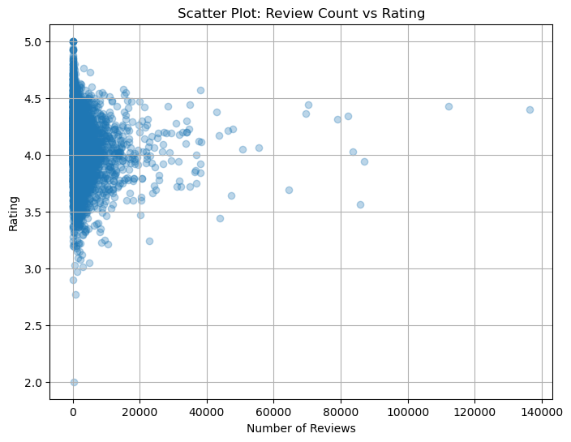

```python
# --------------------------------------- CORRELATION COEFFICIENT ----------------------------------------
# The correlation coefficient gives us an indication on how much two variables are linearly correlated
# one to the other. It is defined as the covariance of the two variables divided by the product of their standard deviations.
# In formula:
# R(x,y) = ( COV (x,y) / sd(x)*sd(y) )

#importing numpy:
import numpy as np

#reading the file and calculating the correlation coefficient with .corrcoef
df_2 = pd.read_csv("/Users/pietro/Documents/UNI/MADE/Data1/lab-02/data/cleaned-goodreads.csv")
corr_coeff = np.corrcoef(df_2['review_count'], df_2['rating'])[0, 1]

#printing
print("-------------------------------------")
print("The correlation coefficient is: ")
print(corr_coeff)
print("-------------------------------------")
# --------------------------------------------------------------------------------------------------------




# ---------------------------------- SCATTER PLOT ----------------------------------------------
#using matlpotlib for plotting
import matplotlib.pyplot as plt

#adjusting the dimensions of the image shown
plt.figure(figsize=(8,6))

#PLOTTING with .scatter function. Alpha sets the transparency of the dots
plt.scatter(df_2['review_count'], df_2['rating'], alpha=0.3)

#VISUALS of the plot: title, lables of the axis and adding a grid
plt.title('Scatter Plot: Review Count vs Rating')
plt.xlabel('Number of Reviews')
plt.ylabel('Rating')
plt.grid(True)
#-----------------------------------------------------------------------------------------------
```

INTERPRETATION OF THE FIGURE From the scatter plot we can see that the higher the number of reviews, the values of rating tend to get more stable in a range between 3.5 and 4.5. For low number of reviews the values of rating stand in a much wider range. This is confirmed by the bell shape that appears on the plot. The correlation coefficient ( -0.0378...) shows that the relationship between these variables is not linear since its value is very close to zero. This aspect is visually confirmed by the scatter plot where we can see that the values are not aligned. Instead they form a dense and wide area.

For the plot our codes were very similar. One of us switched the x and y axis and another used seaborn library for the plot. In the end all worked but we picked this code mostly thinking of how the graph looked like.

## Exercise 7: Calculate the following descriptive statistics for the numerical features (e.g., number of reviews, average rating, etc.):

- Mean
- Median
- Standard Deviation
- Range
- Create a histogram or box plot for at least one of the numerical features, highlighting any skewness or outliers.

### Python Tools: Use pandas for data manipulation and matplotlib or seaborn for visualization.

```python
#----------------------------------- CALCULATING DESCRIPTIVE STATISTICS -------------------------------

# Select the numerical columns to calculate statistics
num_col = ['review_count', 'rating', 'rating_count','year']

# Calculate MEAN, MEDIAN, STANDAR DEVIATION, MAX and MIN for the numerical features
# values are saved in statistics variable
# .agg() is used to apply multiple aggregating functions (mean,median...)
statistics = df_2[num_col].agg(['mean', 'median', 'std', 'min', 'max'])

# Calculate the RANGE as a difference between max and min
statistics.loc['range'] = statistics.loc['max'] - statistics.loc['min']

# Display the calculated descriptive statistics
print("-----------------------------------------------------------")
print("DESCRIPTIVE STATISTICS:")
print("-----------------------------------------------------------")
print(statistics)
print("-----------------------------------------------------------")
#--------------------------------------------------------------------------------------------------------
```

```
-----------------------------------------------------------
DESCRIPTIVE STATISTICS:
-----------------------------------------------------------
         review_count    rating  rating_count         year
mean      2374.331220  4.041997  5.118390e+04  1969.085099
median     936.000000  4.050000  1.807200e+04  2002.000000
std       5493.093328  0.260509  1.376493e+05   185.383169
min          0.000000  2.000000  5.000000e+00 -1500.000000
max     136455.000000  5.000000  2.958974e+06  2014.000000
range   136455.000000  3.000000  2.958969e+06  3514.000000
-----------------------------------------------------------
```

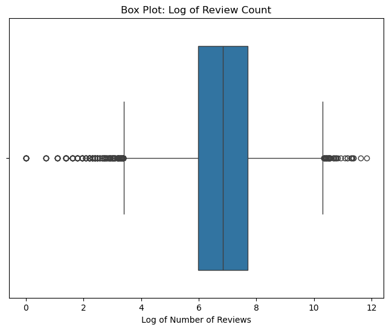

```python
#------------------------------------------ BOX PLOT ------------------------------------------
#importing seaborn
import seaborn as sns

# PLOTTING using a logarithmic scale to handle the skewness. .boxplot produces the boxplot of the review count
# log1p handles zero values safely,calculates the natural logarithm of 1 + x, which is work better than .log()
plt.figure(figsize=(8,6))
sns.boxplot(x=np.log1p(df_2['review_count']))

# VISUALS of the plot
plt.title('Box Plot: Log of Review Count')
plt.xlabel('Log of Number of Reviews')
plt.show()
#-------------------------------------------------------------------------------------------------
```

For the descriptive statistics two of us were calculating each one independently but the best solution we agreed on was the one using the .agg() function. Like this everything can be calculated in one single step. Another important difference was that other codes were plotting a scatter plot. We opted for the boxplot because it really puts a focus on outliers (there are a lot of them if using this method). Another thing to mention is that the final code calculates .log1p() to manage numbers close to 0. Therefore the visual representation is more interesting with a boxplot.